title: “PA1_template1” author: “wenlarry” date: “September 18, 2016” output: html_document: keep_md: yes

Loading and Processing the data

Unzip ’activity_zip in working directory Library: dplyr, ggplot2

```r
knitr::opts_chunk$set(error=TRUE)
```

```r
data<-read.csv("activity.csv")
dat1<-na.omit(data)
as.numeric(dat1$month)
```

```
## numeric(0)
```

```r
View(dat1)
```

```
## Error in View(dat1): X11 dataentry cannot be loaded
```

Total number of steps taken each day

```r
library(dplyr)
Totalsteps<-dat1    %>% group_by (date)%>%summarize(totalsteps=sum(steps,na.rm=TRUE))
                                               View(Totalsteps)
```

```
## Error in View(Totalsteps): X11 dataentry cannot be loaded
```

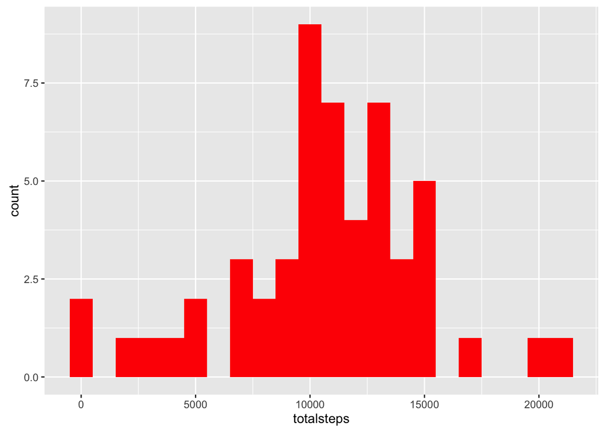

Mean and Median steps each day

```r
mean(Totalsteps$totalsteps)
```

```
## [1] 10766.19
```

```r
median(Totalsteps$totalsteps)
```

```
## [1] 10765
```

Time Series Plot _Average number of days averaged across all days

```r
library(dplyr)
Avsteps<-dat1  %>%group_by(interval)%>% summarize(avsteps=
mean(steps,na.rm=TRUE))
View(Avsteps)
```

```
## Error in View(Avsteps): X11 dataentry cannot be loaded
```

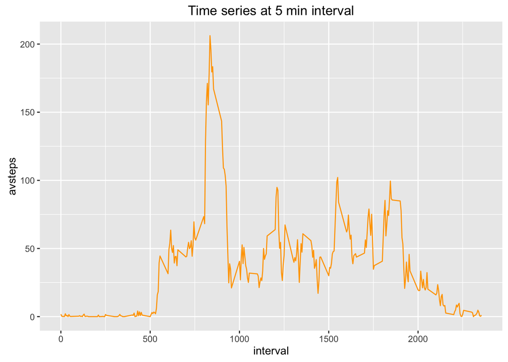

5 min interval that on average contains the max number os steps is 835 with average steps of 206.2

This result can also be obtained from the above dataframe ‘Avsteps’

```r
Avsteps[Avsteps$avsteps==max(Avsteps$avsteps),]
```

```
## # A tibble: 1 x 2
##   interval  avsteps
##      <int>    <dbl>
## 1      835 206.1698
```

Imputing missing values

NAs Total

```r
sum(is.na(data))
```

```
## [1] 2304
```

Use the mean of 5 minute interval for imputation

Create a new dataset that is equal to the original dataset but with missing values substituted

```r
library(dplyr)
dat2<-mutate(data,steps=ifelse(is.na(steps),as.integer
(Avsteps$avsteps),steps))
View(dat2)
```

```
## Error in View(dat2): X11 dataentry cannot be loaded
```

Total number of steps taken each day

```r
library(dplyr)
Totalsteps2<-dat2%>%group_by(date)%>%summarize(totalsteps2=sum(steps,na.rm=TRUE) )
View(Totalsteps2)
```

```
## Error in View(Totalsteps2): X11 dataentry cannot be loaded
```

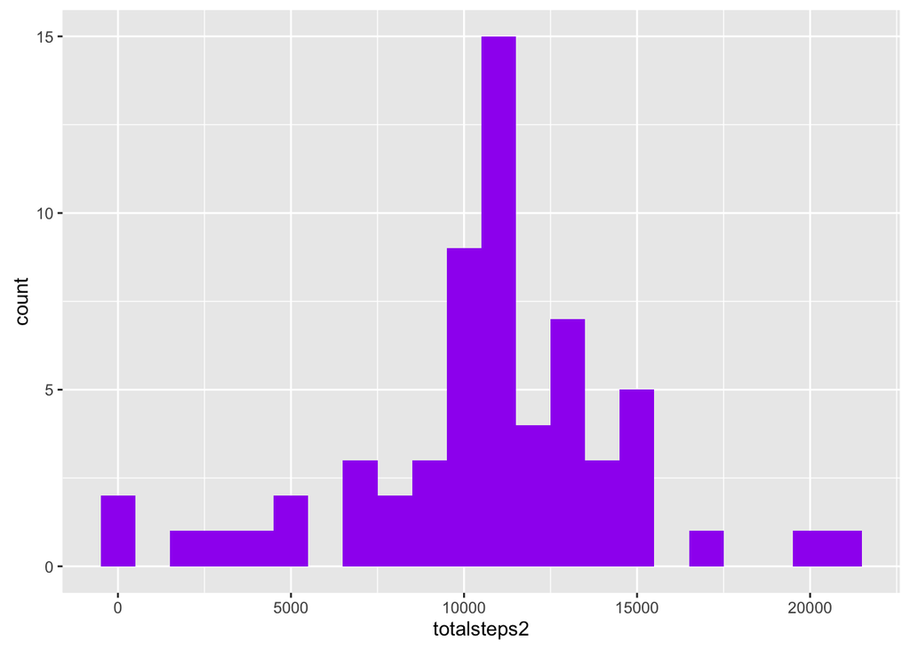

Mean and Madian of steps each day -Without Imputed Values vs With Imputed Values

```r
mean1<-mean(Totalsteps$totalsteps)
mean2<-mean(Totalsteps2$totalsteps2)
mean2-mean1
```

```
## [1] -16.41819
```

```r
median1<-median(Totalsteps$totalsteps)
median2<-median(Totalsteps2$totalsteps2)
median2-median1
```

```
## [1] -124
```

Diffference in activities between weekdays and weekends

Create a new factor variable with 2 levels -‘weekday’ and ‘weekend’

```r
dat2$date<-as.Date(dat2$date)
weekdays1<-c("Monday","Tuesday","Wednesday","Thursday",
            "Friday")
dat2$wday<-c('weekend','weekday')[weekdays    (dat2$date)%in%weekdays1+1L]

table(dat2$wday)
```

```
##
## weekday weekend
##   12960    4608
```

```r
View(dat2)
```

```
## Error in View(dat2): X11 dataentry cannot be loaded
```

Time Series Panel Plot - interval(x axis) and Average Steps(y axis)

```r
library(dplyr)
Avsteps2<-dat2%>%group_by(interval,wday)%>% summarize(avsteps2=mean(steps,na.rm=TRUE))
View(Avsteps2)
```

```
## Error in View(Avsteps2): X11 dataentry cannot be loaded
```

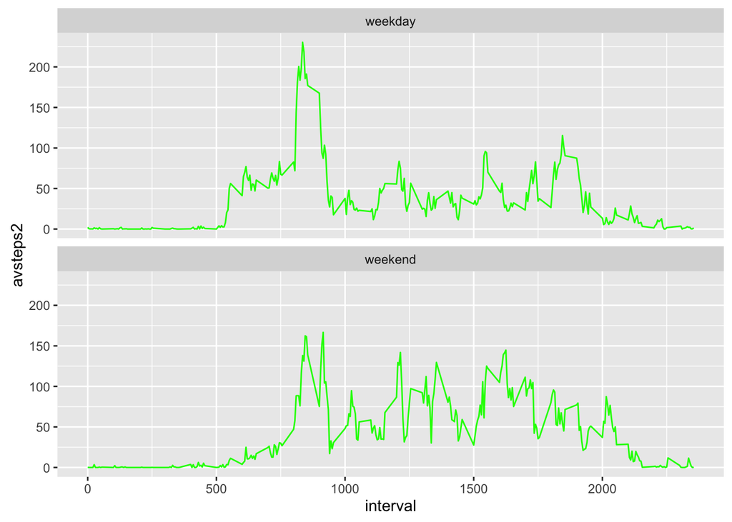

Time Series Single Plot _ An overlay of the time series to provide a clearer distinction

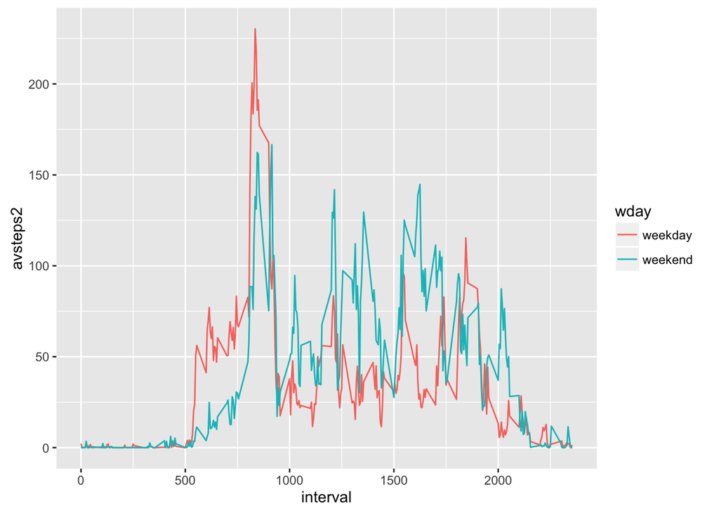